# Variability

Data Analysis for Psychology in R 1

Tom Booth

Click for slides

## Today

- Last lecture we described central tendency.
- Today we discuss variability or dispersion.
  - Range (minimum, maximum, inter-quartile, decile)
  - Summed deviations
  - Absolute deviations
  - Variance
  - Standard deviation

## Learning objectives

- Be able to describe the 5 measures of variability.
- Understand to what data we can apply each measure of variability.
- Understand the pro’s and con’s of each measure.
- Develop an initial understanding of how to calculate in R.

## Data (n=150)

| ID | Degree | StatsScore |
| --- | --- | --- |
| ID101 | Psych | 67 |
| ID102 | Ling | 69 |
| ID103 | Phil | 70 |
| ID104 | Phil | 69 |
| ID105 | Phil | 68 |
| ID106 | Phil | 70 |
| ID107 | Psych | 58 |
| ID108 | Psych | 66 |
| ID109 | Ling | 66 |
| ID110 | Psych | 72 |

## Statistic Score Distribution

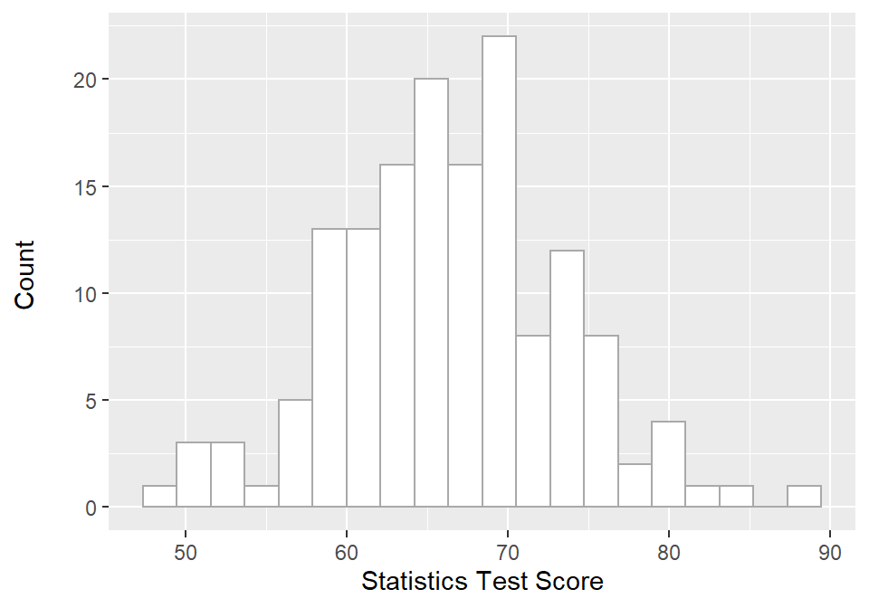

## Range

- The **range** of the data is simply the value between two points.
  - We can define these points in different ways.
- Range is generally used to describe the total range (max - min) of the data.

```r
ex1 %>%
  select_if(is.numeric) %>%
  summarise(
    Variable = names(.),
    Sample = n(),
    Minimum = min(.),
    Maximum = max(.)) %>%
  mutate(Range = Maximum - Minimum)
```

| Variable | Sample | Minimum | Maximum | Range |
| --- | --- | --- | --- | --- |
| StatsScore | 150 | 48 | 88 | 40 |

- Problem: Very sensitive to outliers.

## Inter-quartile range

- The **inter-quartile range (IQR)** is the difference between the 1st and 3rd quartile.
  - Rank the data
  - Split data into four equal blocks.
  - Quartiles are the points which divide these blocks.
  - They fall at 25%, 50% and 75% of rank ordered data.
  - IQR is the difference between 25% and 75%

```r
iqr <- quantile(ex1$StatsScore)
res <- tibble(
  "0%" = iqr[[1]],
  "25%" = iqr[[2]],
  "50%" = iqr[[3]],
  "75%" = iqr[[4]],
  "100%" = iqr[[5]]
)
```

| 0% | 25% | 50% | 75% | 100% |
| --- | --- | --- | --- | --- |
| 48 | 62 | 66.5 | 70 | 88 |

- So our IQR = 8
- We can calculate various quantiles using the `quantile()` function, and the IQR directly using the function `IQR()`
- Problem:
  - Still somewhat sensitive to outliers.
  - Ignores half the data.

## Use of range

- In principle, we can define a range using any two values.
- Commonly researchers will also use deciles (blocks of 10%) to define a range.
  - E.g. Range between 10% and 90%

```r
iqr2 <- quantile(ex1$StatsScore, c(.1, .9))
res2 <- tibble(
  "10%" = iqr2[[1]],
  "80%" = iqr2[[2]],
)
```

| 10% | 80% |
| --- | --- |
| 58.9 | 75.1 |

- So the range across 80% of the ranked data is 16.2.
- Ranges rely on **rank-ordered data** .
  - Hence they are most often used alongside the median as a measure of central tendency.

## Variation around the mean

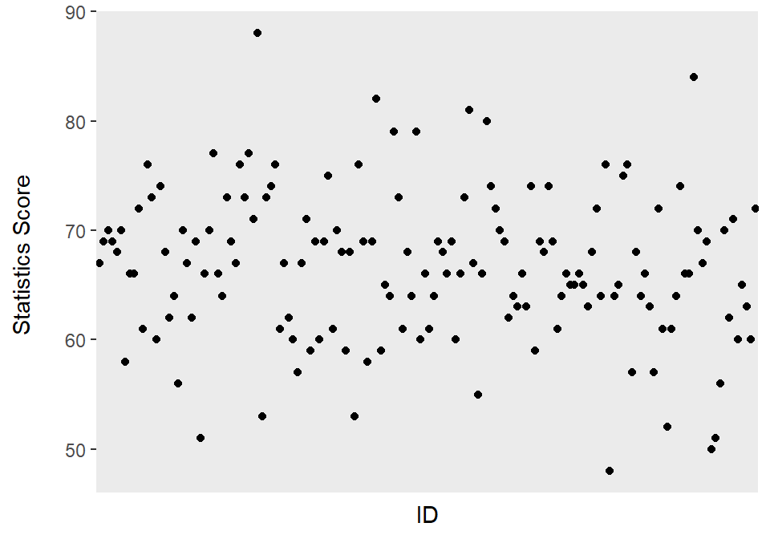

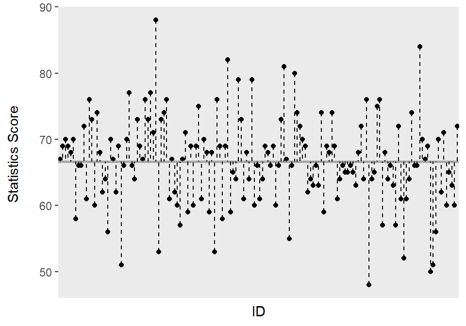

## Sum of deviations

- We could just add up the amount by which each observation differs from the mean.
- This is called the **sum of deviations.**

$$S = \sum_{i=1}^{N}{(x_i - \bar{x})}$$

- $x_i$ = individual observations
- $\bar{x}$ = mean of $x$

## Calculation

| ID | StatsScore | Mean | Deviance |
| --- | --- | --- | --- |
| ID101 | 67 | 67.5 | -0.5 |
| ID102 | 69 | 67.5 | 1.5 |
| ID103 | 70 | 67.5 | 2.5 |
| ID104 | 69 | 67.5 | 1.5 |
| ID105 | 68 | 67.5 | 0.5 |
| ID106 | 70 | 67.5 | 2.5 |
| ID107 | 58 | 67.5 | -9.5 |
| ID108 | 66 | 67.5 | -1.5 |
| ID109 | 66 | 67.5 | -1.5 |
| ID110 | 72 | 67.5 | 4.5 |

## Problem: Sum of deviations

```r
ex1 %>%
  summarise(
    Variable = "Statistics Test Score",
    "Sum Deviation" = round(sum(StatsScore - mean(StatsScore)),2)
  )
```

| Variable | Sum Deviation |
| --- | --- |
| Statistics Test Score | 0 |

- The positive and negative values cancel.
- This means S will always be 0 when calculated around the mean.

## Sum of absolute deviations

- Suppose we just ignored the direction of the difference, and just considered the magnitude of the difference?
- This is the sum of *absolute* deviations.

$$S_{abs} = \sum_{i=1}^{N}|{(x_i - \bar{x})}|$$

- Here the || are read as absolute, which means that we remove the sign.

| ID | StatsScore | Mean | Deviance | Absolute |
| --- | --- | --- | --- | --- |
| ID101 | 67 | 67.5 | -0.5 | 0.5 |
| ID102 | 69 | 67.5 | 1.5 | 1.5 |
| ID103 | 70 | 67.5 | 2.5 | 2.5 |
| ID104 | 69 | 67.5 | 1.5 | 1.5 |
| ID105 | 68 | 67.5 | 0.5 | 0.5 |
| ID106 | 70 | 67.5 | 2.5 | 2.5 |
| ID107 | 58 | 67.5 | -9.5 | 9.5 |
| ID108 | 66 | 67.5 | -1.5 | 1.5 |
| ID109 | 66 | 67.5 | -1.5 | 1.5 |
| ID110 | 72 | 67.5 | 4.5 | 4.5 |

```r
ex1 %>%
  summarise(
    Variable = "Statistics Test Score",
    "Sum Deviation" = round(sum(StatsScore - mean(StatsScore)),2),
    "Abs Sum Deviation" =  round(sum(abs(StatsScore - mean(StatsScore))),2)
  )
```

| Variable | Sum Deviation | Abs Sum Deviation |
| --- | --- | --- |
| Statistics Test Score | 0 | 796 |

- Problem:
  - As sample gets bigger, the sum of deviations continues to grow.

## Mean sum of absolute deviations

- To resolve, we could scale it by sample size.
- Thus we get the *mean sum of absolute deviations.*

$$\bar{S_{abs}} = \frac{\sum_{i=1}^{N}|{(x_i - \bar{x})}|}{N}$$

- Tells us how far *on average* all points are from the centre of the values.

```r
ex1 %>%
  summarise(
    Variable = "Statistics Test Score",
    "Sum Deviation" = round(sum(StatsScore - mean(StatsScore)),2),
    "Abs Sum" =  round(sum(abs(StatsScore - mean(StatsScore))),2),
    "Mean Abs Sum" = round(sum(abs(StatsScore - mean(StatsScore)))/length(StatsScore),2)
  )
```

| Variable | Sum Deviation | Abs Sum | Mean Abs Sum |
| --- | --- | --- | --- |
| Statistics Test Score | 0 | 796 | 5.31 |

- Divide the absolute sum by N.

## Variance

- Instead of using absolute values to deal with negatives, we could instead square the differences.
- This is called the *variance* .

$$\sigma^2 = \frac{\sum_{i=1}^{N}{(x_i - \bar{x})}^2}{N}$$

- Variance is the mean squared deviation from the mean.
- $\sigma^2$ = variance (Greek letter lower case sigma)

| ID | StatsScore | Mean | Deviance | Deviance_sq |
| --- | --- | --- | --- | --- |
| ID101 | 67 | 67.5 | -0.5 | 0.25 |
| ID102 | 69 | 67.5 | 1.5 | 2.25 |
| ID103 | 70 | 67.5 | 2.5 | 6.25 |
| ID104 | 69 | 67.5 | 1.5 | 2.25 |
| ID105 | 68 | 67.5 | 0.5 | 0.25 |
| ID106 | 70 | 67.5 | 2.5 | 6.25 |
| ID107 | 58 | 67.5 | -9.5 | 90.25 |
| ID108 | 66 | 67.5 | -1.5 | 2.25 |
| ID109 | 66 | 67.5 | -1.5 | 2.25 |
| ID110 | 72 | 67.5 | 4.5 | 20.25 |

```r
ex1 %>%
  summarise(
    Variable = "Statistics Test Score",
    "Sum Deviation" = round(sum(StatsScore - mean(StatsScore)),2),
    "Abs Sum" =  round(sum(abs(StatsScore - mean(StatsScore))),2),
    "Mean Abs Sum" = round(sum(abs(StatsScore - mean(StatsScore)))/length(StatsScore),2),
    Variance = round((sum((StatsScore - mean(StatsScore))^2))/length(StatsScore),2)
  )
```

| Variable | Sum Deviation | Abs Sum | Mean Abs Sum | Variance |
| --- | --- | --- | --- | --- |
| Statistics Test Score | 0 | 796 | 5.31 | 47.18 |

- Problem:
  - Our units here are not quite right.
  - Variance is the mean **squared** deviation from the mean.

## Standard deviation

- What about a measure of variation in the same units as the mean/variable?
- The *standard deviation.*
- The standard deviation is the square root of the variance.
  - This fixes our unit/scaling problem.

$$\sigma = \sqrt{\frac{\sum_{i=1}^{N}{(x_i - \bar{x})}^2}{N}}$$

```r
ex1 %>%
  summarise(
    Variable = "Statistics Test Score",
    "Sum Deviation" = round(sum(StatsScore - mean(StatsScore)),2),
    "Abs Sum" =  round(sum(abs(StatsScore - mean(StatsScore))),2),
    "Mean Abs Sum" = round(mean(abs(StatsScore - mean(StatsScore))),2),
    Variance = round((sum((StatsScore - mean(StatsScore))^2))/length(StatsScore),2),
    SD = round(sqrt((sum((StatsScore - mean(StatsScore))^2))/length(StatsScore)),2)
  )
```

| Variable | Sum Deviation | Abs Sum | Mean Abs Sum | Variance | SD |
| --- | --- | --- | --- | --- | --- |
| Statistics Test Score | 0 | 796 | 5.31 | 47.18 | 6.87 |

## Easier options

```r
ex1 %>%
  summarise(
    Variable = "Statistics Test Score",
    "Sum Deviation" = round(sum(StatsScore - mean(StatsScore)),2),
    "Abs Sum" =  round(sum(abs(StatsScore - mean(StatsScore))),2),
    "Mean Abs Sum" = round(mean(abs(StatsScore - mean(StatsScore))),2),
    Variance = round(var(StatsScore),2),
    SD = round(sd(StatsScore),2)
  )
```

[output not shown]

## Which measure should we use?

| Variable Type | Central Tendency | Dispersion |
| --- | --- | --- |
| Categorical (Nominal) | Mode | Frequency Table |
| Categorical (Ordered) | Mode/Median | Range |
| Continuous | Mean (any in fact) | Variance & Standard Deviation |
| Count | Mode (mean) | Range (Variance & SD) |

- Depends on the level of measurement.

## A few extra bits?

- You may come across the mathematical language of *moments.*
- Moments describe the shape of a set of points
  - Mean
  - Variance
  - Skew
  - Kurtosis

## Skew

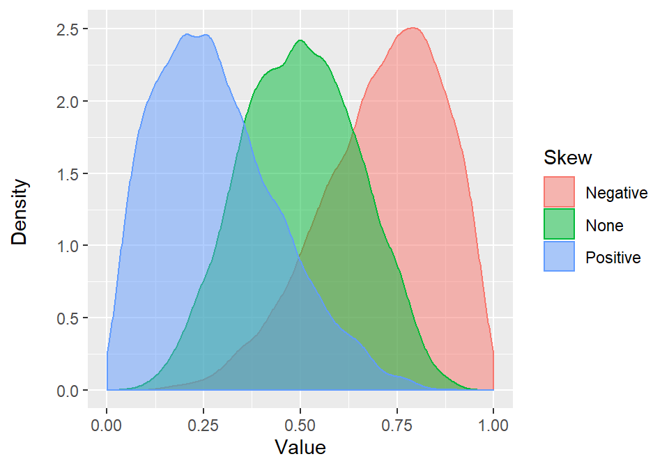

- Is a measure of asymmetry of a distribution.

## Kurtosis

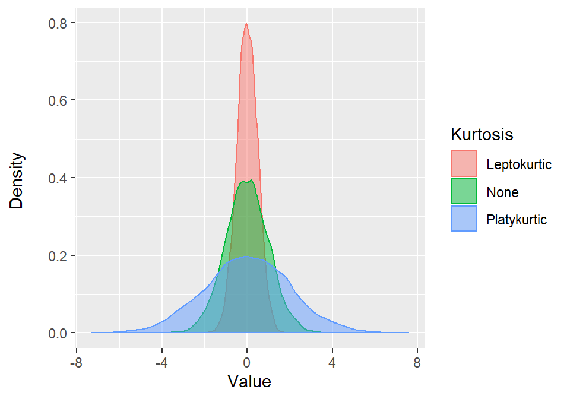

- Kurtosis is a measure of the flatness of the peak and the fatness of the tails of the distribution.

## Do they matter?

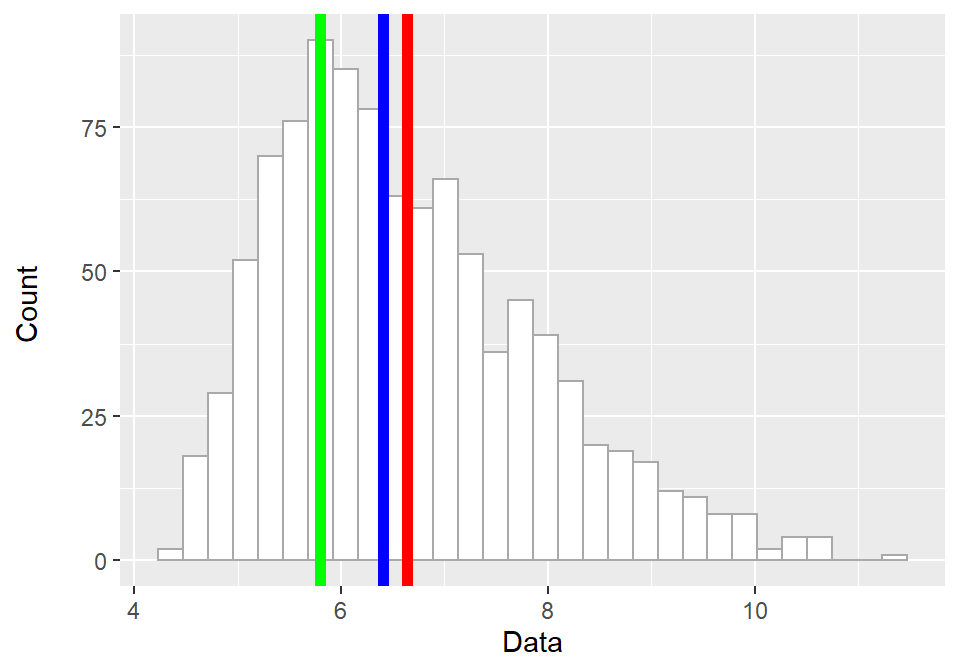

- It can make a difference in how we describe data.
- Both skew and kurtosis impact the **normality** of the distribution of the data.

## Descriptive statistics can deceive

| set | mean | sd |
| --- | --- | --- |
| x1 | 9.0 | 3.32 |
| x2 | 9.0 | 3.32 |
| x3 | 9.0 | 3.32 |
| x4 | 9.0 | 3.32 |
| y1 | 7.5 | 2.03 |
| y2 | 7.5 | 2.03 |
| y3 | 7.5 | 2.03 |
| y4 | 7.5 | 2.03 |

## Always visualize data

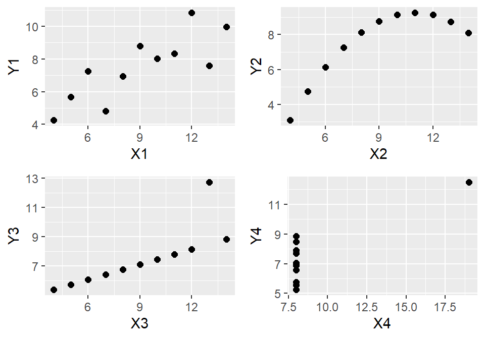

## Tasks for this week…

1. Finish any existing tasks from lab 4.
2. Reading: Linked at the top of lab 5.
3. Quiz 5: Central tendency
   - **This quiz counts**
   - Live now (as of Monday at 09:00).
   - Closes Sunday at 17:00

## Recommendations of the week

- Podcast: [Ineos159](https://www.youtube.com/watch?v=7XW63dM_1d0) Preview documentary
- Recipe: [Roasted Veggie Lasagna](https://www.bbcgoodfood.com/recipes/roasted-vegetable-lasagne)
- Book: [Stoner](https://www.theguardian.com/books/2013/dec/13/stoner-john-williams-julian-barnes), John Williams
- Thing to do: [Portobello Beach](https://www.visitscotland.com/info/towns-villages/portobello-beach-p730811)
- Coffee/food Place: [Mary’s Milk Bar](http://www.marysmilkbar.com/)